# R Notebook

```r
library(tidyverse)
```

# 2 project_management analysis

# Load the data into a dataframe project

```r
project <- read_csv("../data/project_management.csv")
```

# Plot the data, taking estimated_length as the independent variable and actual_length as the dependent variable.

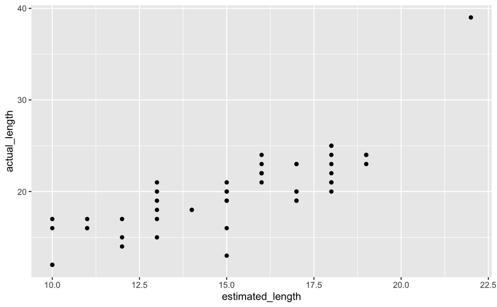

```r
project %>%
  ggplot(aes(estimated_length, actual_length)) +
  geom_point()
```

# Label the data points with their row number in the data frame using geom_text() [Hint - you can pass aes(label = 1:nrow(project)) to this layer to generate row index labels]

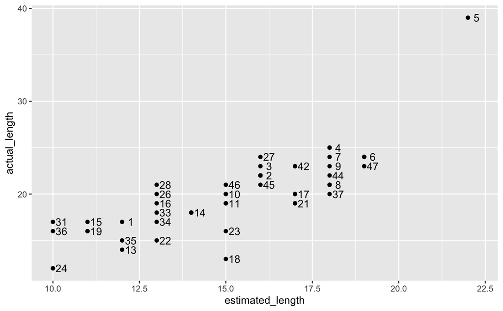

```r
project %>%
  ggplot(aes(estimated_length, actual_length)) +
  geom_point() +
  geom_text(aes(label = 1:nrow(project)), nudge_x = 0.25, check_overlap = TRUE)
```

# Identify by eye any points you think might be outliers and note their labels.

Outliers: 5, 18, 24

# Further split your outliers into those you think are ‘influential’ or ‘non-influential’ based on a visual assessment of their leverage.